# presentation-live

## Liší se vztah délky a zadní šířky krunýře mezi samicemi a samci?

BIOSTATISTIKA

L08

Interakce prediktorů

cuni-natur-biostatistics.github.io/materialy.html

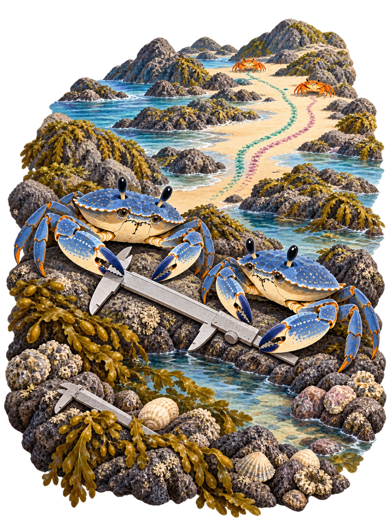

Ilustrace vytvořená pomocí AI.

## Co vlastně na krabovi měříme?

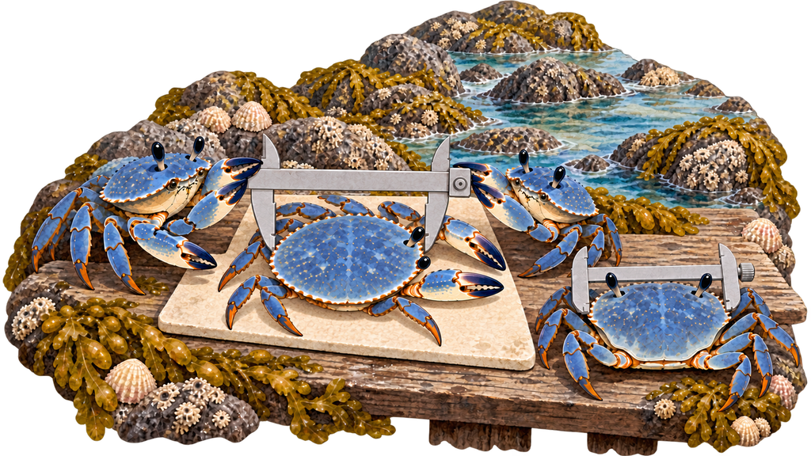

Ilustrace vytvořená pomocí AI.

**Délka krunýře** a **zadní šířka krunýře** jsou dvě měření téhož kraba.

## Co si pamatujete z minulé lekce?

Odpovězte samostatně na tři krátké otázky. Na telefonu neuvidíte odpovědi ostatních; společné výsledky otevřeme až po hlasování.

[figure not shown]

[Otevřít dotazník v novém okně](https://pollslive.com/p/l08-opakov-n-p-edchoz-lekce-2026-27-8ew3l9ve)

## Jak odpovídala skupina?

[interactive chart not shown]

[Otevřít výsledky mimo prezentaci](https://pollslive.com/p/l08-opakov-n-p-edchoz-lekce-2026-27-8ew3l9ve?view=results)

## Co znamená záporný koeficient roční teploty v modelu s roční i maximální teplotou?

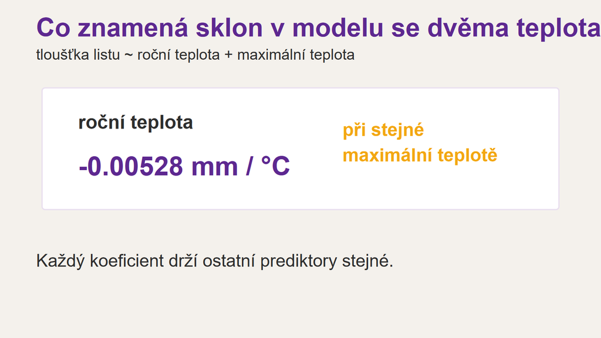

- Celkovou změnu tloušťky listu při zvýšení obou teplot o 1 °C.
- Rozdíl průměrné roční teploty mezi původními a zavlečenými populacemi.
- Vztah roční teploty k tloušťce listu bez ohledu na maximální teplotu.
- Změnu odhadované tloušťky listu při zvýšení roční teploty o 1 °C, když maximální teplotu držíme stejnou.

Správná odpověď: Změnu odhadované tloušťky listu při zvýšení roční teploty o 1 °C, když maximální teplotu držíme stejnou.

V modelu s více prediktory čteme každý sklon při stejné hodnotě ostatních prediktorů. Koeficient proto není totožný s jednoduchým jednoprediktorovým sklonem.

## Kterému odhadu z modelu se dvěma teplotami bychom měli více důvěřovat?

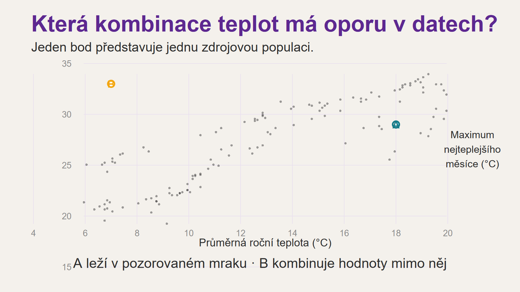

- Odhadu pro kombinaci roční a maximální teploty, která leží uvnitř pozorovaného mraku bodů.
- Odhadu pro libovolnou kombinaci uvnitř rozsahu každé teploty, i když se tato dvojice v datech nevyskytuje.
- Odhadu pro kombinaci nejnižší roční a nejvyšší maximální teploty, protože využívá oba extrémy.
- Všem odhadům stejně, protože lineární model umí spočítat každou číselnou kombinaci.

Správná odpověď: Odhadu pro kombinaci roční a maximální teploty, která leží uvnitř pozorovaného mraku bodů.

Model výpočet provede i mimo společně pozorované kombinace, ale takový odhad je extrapolace. Opora je silnější uvnitř mraku skutečných kombinací prediktorů.

## Prohodíme pořadí dvou korelovaných teplot ve formuli. Co se může změnit?

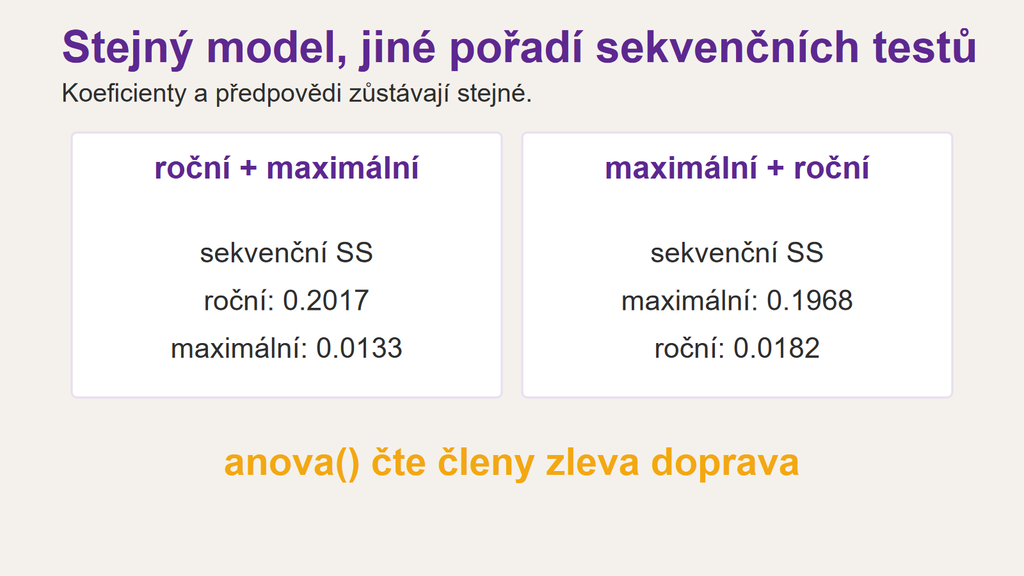

- Koeficienty modelu i jeho předpovědi.
- Koeficienty se nezmění, ale sekvenční tabulka z anova() může přidělit sdílenou informaci jinak.
- Pouze počet pozorování v modelu.
- Nic; koeficienty, předpovědi i každý řádek sekvenční anova() musí zůstat stejné.

Správná odpověď: Koeficienty se nezmění, ale sekvenční tabulka z anova() může přidělit sdílenou informaci jinak.

Pořadí prediktorů nemění fit ani koeficienty stejného modelu. Sekvenční anova() však testuje členy v pořadí ve formuli, takže u korelovaných prediktorů se její řádky mohou změnit.

## Výsledky učení

Po absolvování této přednášky budete schopni:

- rozpoznat biologickou otázku, ve které vztah jednoho prediktoru k odezvě závisí na druhém prediktoru;
- fitovat model s interakcí a zobrazit jeho předpovědi pro kombinace číselných i skupinových prediktorů;
- vyložit koeficienty modelu s interakcí jako podmíněné a porovnávat skupiny nebo různé hodnoty prediktoru pomocí předpovědí;
- vysvětlit interakci dvou skupinových prediktorů jako rozdíl dvou rozdílů;
- omezit závěr na pozorovaný rozsah dat a na souvislost v pozorovacích datech.

# Platí rovnoběžné přímky i pro kraby?

## Proč by se samice a samci mohli lišit tvarem krunýře?

Co víme o krabech

- Zadní část krunýře leží zhruba nad zadečkem.
- Samice pod zadečkem nosí vajíčka.
- Samice a samci se liší poměrem zadní šířky a délky krunýře.

Bude rozdíl v zadní šířce mezi stejně dlouhou samicí a samcem stejný u malých i velkých krabů?

Campbell a Mahon (1974), *Australian Journal of Zoology* 22: 417–425.

## Jeden bod představuje jednoho kraba

```r
data_krabi_vse <-
  read.csv(file = "data/krabi.csv")

# Modrá forma, pohlaví, délka a zadní šířka
data_krabi <-
  data_krabi_vse[
    data_krabi_vse$sp == "B",
    c("sex", "CL", "RW")
  ]
names(data_krabi) <-
  c("pohlavi", "delka_krunyre_mm",
    "zadni_sirka_mm")
data_krabi$pohlavi <-
  factor(
    x = data_krabi$pohlavi,
    levels = c("F", "M"),
    labels = c("samice", "samec")
  )
head(x = data_krabi, n = 3)
```

```
  pohlavi delka_krunyre_mm zadni_sirka_mm
1   samec             16.1            6.7
2   samec             18.1            7.7
3   samec             19.0            7.8
```

100 krabů

- 🔵 modrá barevná forma
- 50 samic · 50 samců
- délka krunýře v mm
- zadní šířka v mm

Campbell a Mahon (1974) · `data/krabi.csv`

## Co naznačují měření krabů?

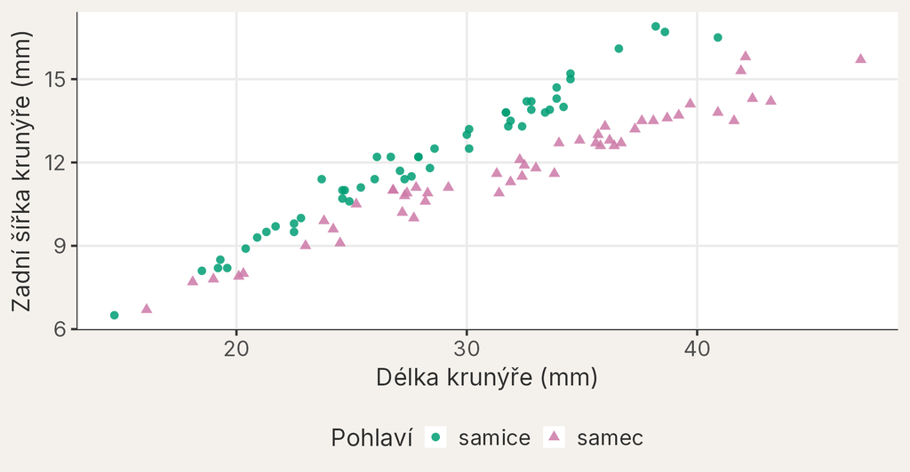

1. Jaký je směr vztahu?
2. Kde se skupiny překrývají?
3. Vypadají oba sklony stejně?

## Aditivní model kreslí rovnoběžné přímky

```r
mod_rovnobezne <-
  lm(
    formula = zadni_sirka_mm ~ delka_krunyre_mm + pohlavi,
    data = data_krabi
  )
```

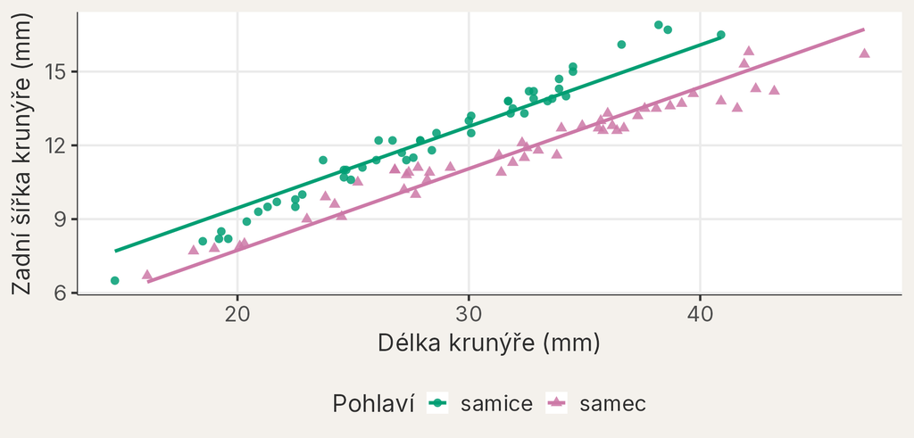

`+` dovoluje posun mezi skupinami, ale ukládá jim společný sklon.

## Zůstává rozdíl mezi pohlavími při každé délce stejný?

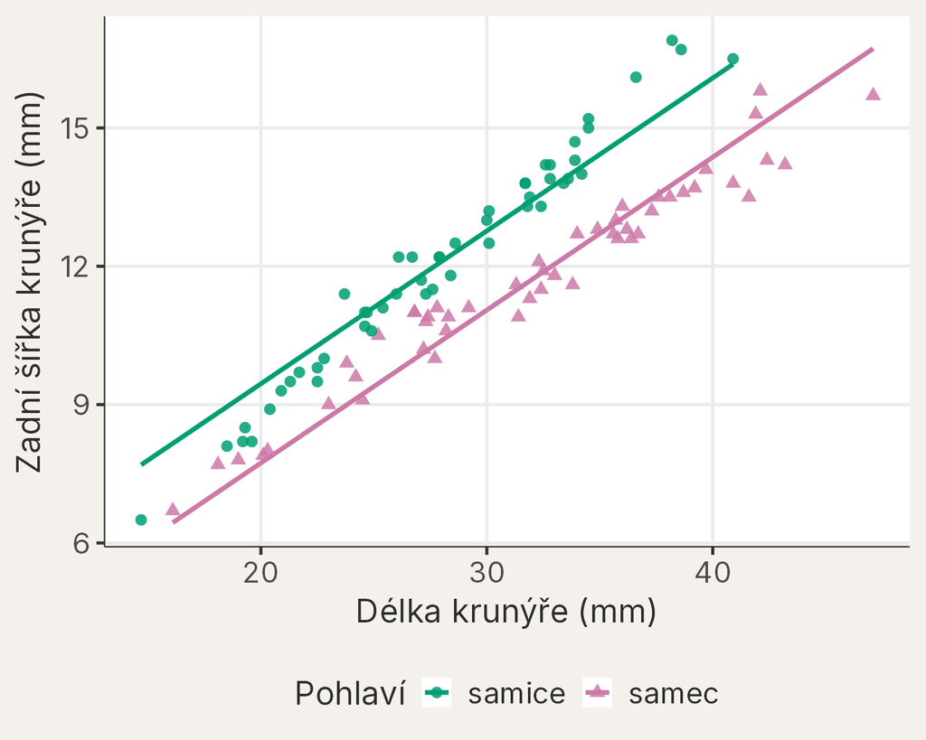

Ve dvojici

Porovnejte svislou vzdálenost přímek u kratších a delších krabů.

Sedí přímky k bodům i na koncích rozsahu?

## Data naznačují různé sklony

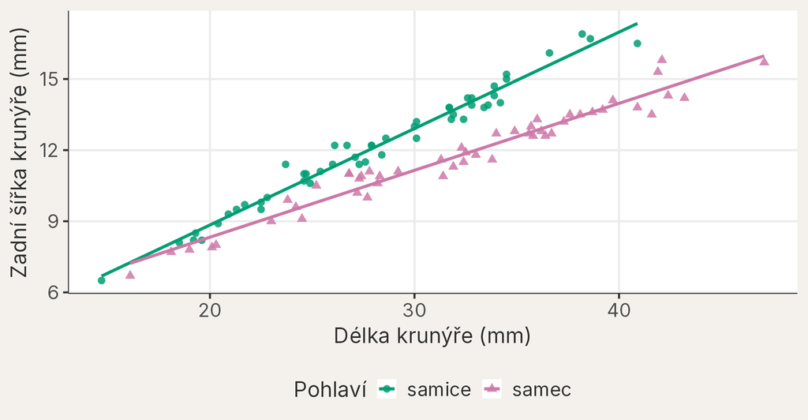

Svislá vzdálenost mezi přímkami se s délkou mění.

## Když se rozdíl mění, mluvíme o interakci

Aditivní model

Rozdíl mezi pohlavími je při každé délce stejný.

Rovnoběžné přímky

Model s interakcí

Rozdíl mezi pohlavími se mění s délkou.

Různé sklony

**Interakce:** vztah délky a zadní šířky závisí na pohlaví.

## Jak zapsat model s interakcí?

1. `zadni_sirka_mm ~ delka_krunyre_mm + pohlavi`
2. `zadni_sirka_mm ~ delka_krunyre_mm + pohlavi + delka_krunyre_mm:pohlavi`
3. `zadni_sirka_mm ~ delka_krunyre_mm * pohlavi`

`x * y` je zkratka pro `x + y + x:y`; dvojtečka označuje interakční člen.

## Model s interakcí dovoluje dvěma pohlavím různé sklony

```r
mod_interakce <-
  lm(
    formula = zadni_sirka_mm ~ delka_krunyre_mm * pohlavi,
    data = data_krabi
  )
```

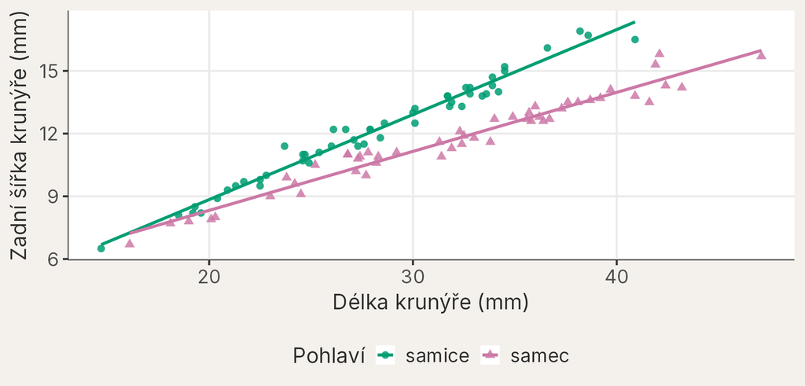

Každou přímku kreslíme jen přes délky zastoupené v její skupině.

## Co model odhaduje pro dva stejně dlouhé kraby?

```r
# Společná délka uvnitř rozsahu obou pohlaví
delka_porovnani_mm <- 30
```

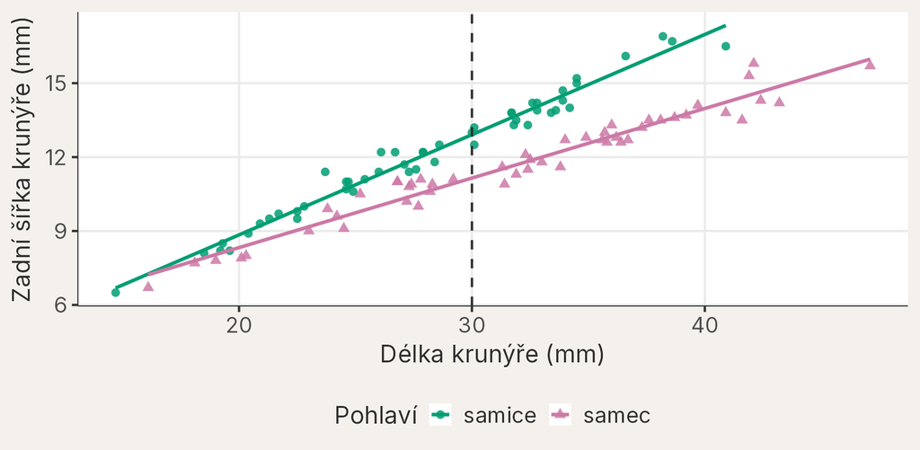

Která přímka je při 30 mm výše? O kolik přibližně?

## Dva odhady při stejné délce krunýře

```r
data_porovnani <-
  data.frame(
    delka_krunyre_mm = rep(x = delka_porovnani_mm, times = 2),
    pohlavi = c("samice", "samec")
  )

data_porovnani$odhad_sirky_mm <-
  predict(
    object = mod_interakce,
    newdata = data_porovnani
  )

data_porovnani
```

```
  delka_krunyre_mm pohlavi odhad_sirky_mm
1               30  samice       12.91000
2               30   samec       11.14947
```

## Samec má při 30 mm užší zadní část krunýře

**● Samice**

12,91 mm

**▲ Samec**

11,15 mm

**Samec − samice**

−1,76 mm

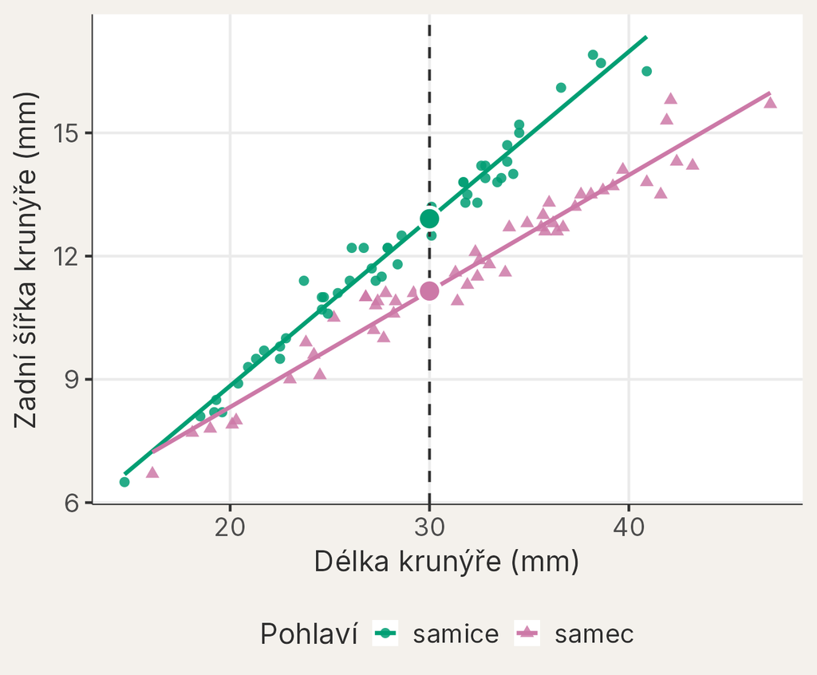

## Co už můžeme říci o stejně dlouhých krabech?

Co víme

- Zadní šířka roste s délkou u obou pohlaví.
- Samci mají pomalejší sklon.
- Při 30 mm má samec zadní šířku o 1,76 mm menší.

Co ještě nevíme

- Jak tento výsledek vyjadřují koeficienty modelu?
- Jak přesně známe rozdíl sklonů?

# Koeficienty interakčního modelu

## Jaké jsou koeficienty v `summary()`?

```r
souhrn_interakce <-
  summary(object = mod_interakce)

round(
  x = souhrn_interakce$coefficients,
  digits = 3
)
```

```
                              Estimate Std. Error t value Pr(>|t|)
(Intercept)                      0.708      0.294   2.409    0.018
delka_krunyre_mm                 0.407      0.010  39.742    0.000
pohlavisamec                     1.973      0.400   4.928    0.000
delka_krunyre_mm:pohlavisamec   -0.124      0.013  -9.450    0.000
```

Pro výklad nám stačí sloupec **Estimate**.

## První dva koeficienty popisují referenční samice

`(Intercept)`

0,708 mm

Odhad pro samici při délce **0 mm** (hypotetický krab).

`delka_krunyre_mm`

+0,407 mm/mm

Sklon samičí přímky: samice delší o 1 mm má odhadem širší zadní část.

## Koeficient pohlaví porovnává skupiny při délce 0 mm

`pohlavisamec` = +1,973 mm

Rozdíl **samec − samice**, když `delka_krunyre_mm = 0`.

Není to:

- rozdíl při každé délce;
- rozdíl při 30 mm;
- průměrný rozdíl mezi všemi samci a samicemi.

**Biologicky smysluplné srovnání získáme z předpovědí uvnitř dat.**

## Interakční koeficient mění sklon samců vůči samicím

Sklon samic

0,4067 mm/mm

Rozdíl sklonů samec − samice

−0,1245 mm/mm

$$\text{sklon samců}
=
\text{0,4067}
+
(\text{−0,1245})
\approx
\text{0,282}\ \text{mm/mm}$$

95% interval spolehlivosti rozdílu sklonů: −0,151 až −0,098 mm/mm

## Rozdíl při 30 mm skládají dva známé příspěvky

Rozdíl **samec − samice při 30 mm** tvoří:

1. rozdíl mezi pohlavími při délce 0 mm: +1,9731 mm;
2. 30 mm × změna rozdílu o −0,1245 mm na každý milimetr délky.

$$\text{rozdíl při } 30\ \text{mm}
=
\text{1,9731}
+ 30 \times (\text{−0,1245})
\approx
\mathbf{\text{−1,76}\ \text{mm}}$$

Obecně pro délku $x$, kde $\beta$ označuje koeficient modelu:

$$\text{rozdíl}(x)=\beta_{\text{samec}}+x\,\beta_{\text{délka:samec}}$$

Je to stejný rozdíl, který jsme odečetli z předpovědí.

## Platí koeficient `pohlavisamec` při každé délce?

**A)** Ano, při každé délce.

**B)** Ne, pouze při délce 0 mm.

**C)** Ne, pouze při délce 30 mm.

Při jiné délce musíme přidat příspěvek interakčního koeficientu.

## Jak dobře přímky popisují změřené kraby?

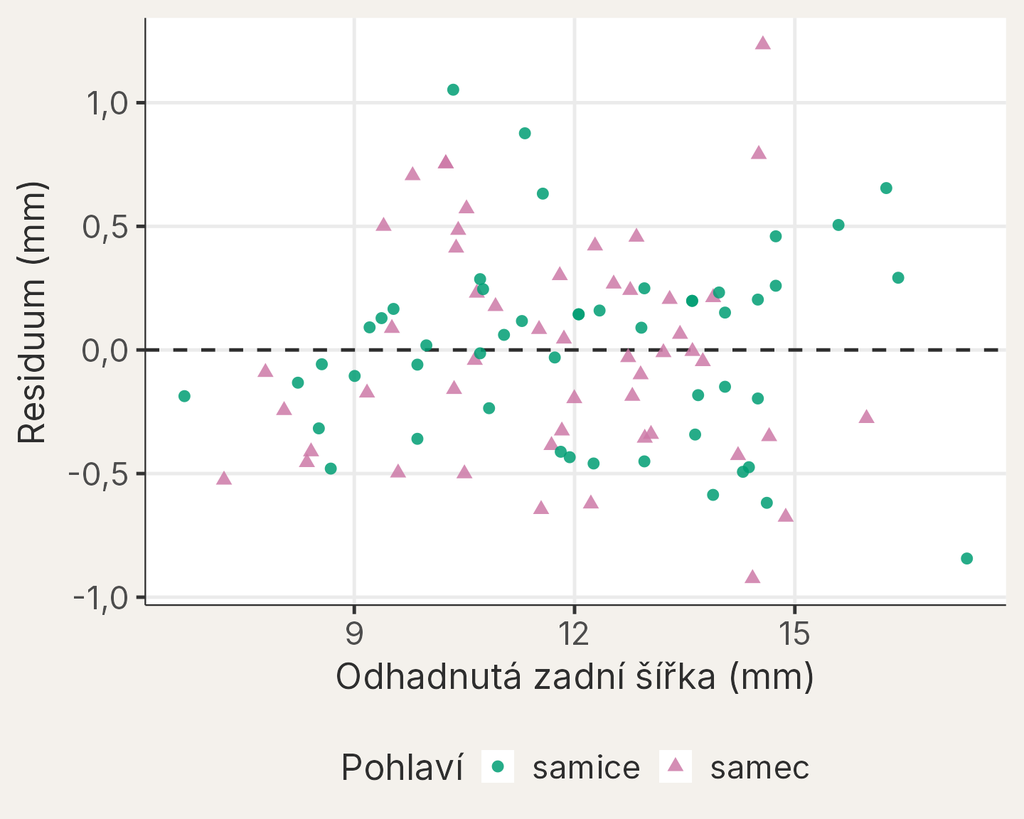

Residua leží kolem nuly bez oblouku a s podobným rozptylem u malých i velkých krabů.

Graf neověří příčinu ani platnost mimo pozorované délky.

## Co víme o rozdílu mezi samicemi a samci modré formy?

Bude rozdíl v zadní šířce mezi stejně dlouhou samicí a samcem stejný u malých i velkých krabů?

Co data ukazují

- Sklon samic 0,407, samců 0,282 mm/mm.
- Rozdíl samec − samice se mění o −0,124 mm na 1 mm délky (95% interval spolehlivosti −0,151 až −0,098).
- Při 30 mm: samec − samice −1,76 mm.

Co zůstává otevřené

- Proč se pohlaví liší: data jsou pozorovací.
- Platí to i pro kraby mimo tento vzorek?
- A pro kraby menší nebo větší, než jsme změřili?

# Když jsou oba prediktory skupiny

## Liší se rozdíl mezi pohlavími u modré a oranžové formy?

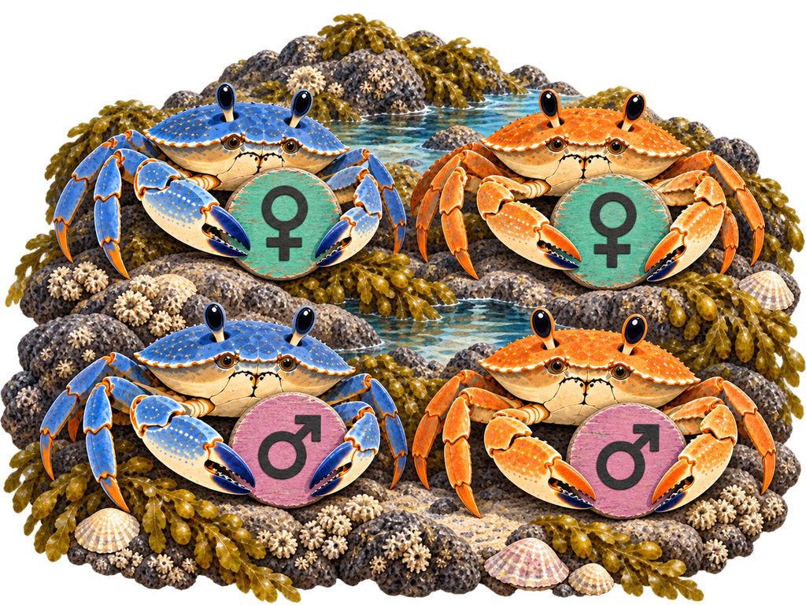

Ilustrace vytvořená pomocí AI.

Odezva

Délka krunýře (mm)

Dva skupinové prediktory

Barevná forma · pohlaví

Mění se rozdíl **samec − samice** mezi barevnými formami?

Do každé skupiny vybrali autoři stejný počet krabů, takže průměrné délky závisejí i na výběru.

## Jaké délky vidíme ve čtyřech skupinách?

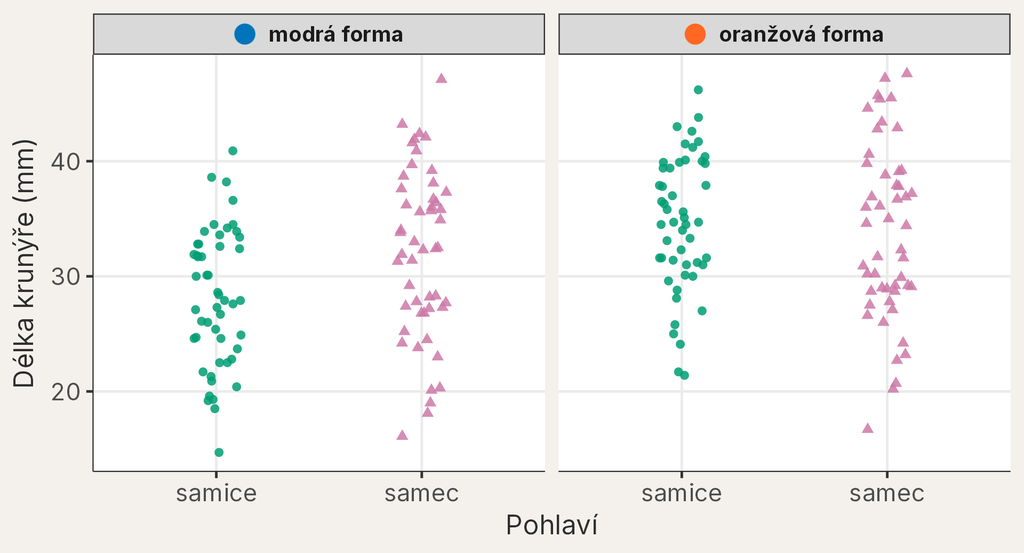

Každý bod je jeden krab. Autoři vybrali do každé skupiny 50 krabů.

## Je rozdíl mezi samci a samicemi u obou forem stejný?

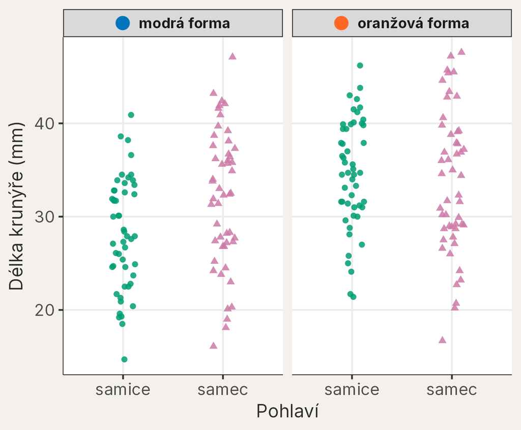

Minuta bez hovoru

Napište pro každou formu:

- kdo má vyšší průměr;
- zda čekáte podobně velký rozdíl;
- jednu větu, kterou z bodů říci nemůžeme.

## Průměry ukazují dva různé rozdíly

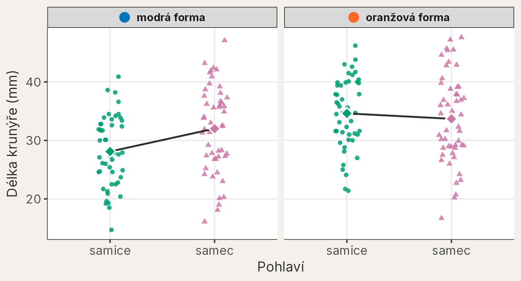

Body, osy i náhodné posunutí jsou stejné. Přibyly pouze průměry a spojnice.

## Jak velký je rozdíl samec minus samice v každé formě?

🔵 Modrá forma

$$\text{32,01}
-
\text{28,10}
=
\mathbf{\text{+3,91}\ \text{mm}}$$

🟠 Oranžová forma

$$\text{33,69}
-
\text{34,62}
=
\mathbf{\text{−0,93}\ \text{mm}}$$

U modré formy jsou samci v průměru delší, u oranžové o něco kratší.

## Interakce je rozdíl dvou rozdílů

**Rozdíl dvou rozdílů** $\Delta$ = rozdíl u 🟠 oranžové formy − rozdíl u 🔵 modré formy

$$\Delta
=
(\text{−0,93})
-
(\text{+3,91})
=
\mathbf{\text{−4,84}\ \text{mm}}$$

Rozdíl mezi pohlavími se při přechodu od modré k oranžové formě změní o −4,84 mm.

## `forma * pohlavi` zapíše všechny čtyři kombinace

`forma + pohlavi + forma:pohlavi = forma * pohlavi`; referenční kombinace je modrá forma a samice.

```r
mod_formy <-
  lm(
    formula = delka_krunyre_mm ~ forma * pohlavi,
    data = data_formy
  )

round(
  x = summary(object = mod_formy)$coefficients,
  digits = 3
)
```

```
                           Estimate Std. Error t value Pr(>|t|)
(Intercept)                  28.102      0.950  29.584    0.000
formaoranžová                 6.516      1.343   4.851    0.000
pohlavisamec                  3.912      1.343   2.912    0.004
formaoranžová:pohlavisamec   -4.842      1.900  -2.549    0.012
```

## Který údaj je rozdíl samec − samice v oranžové formě?

| Koeficient | Odhad (mm) |
| --- | --- |
| `(Intercept)` | 28,102 |
| `formaoranžová` | +6,516 |
| `pohlavisamec` | +3,912 |
| `formaoranžová:pohlavisamec` | −4,842 |

**A)** `pohlavisamec`

**B)** `formaoranžová:pohlavisamec`

**C)** `pohlavisamec` + `formaoranžová:pohlavisamec`

**D)** `formaoranžová`

+3,91 + (−4,84) = −0,93 mm: stejný rozdíl, jaký jsme spočítali z průměrů oranžové formy.

## Co znamená každý ze čtyř koeficientů?

**`(Intercept)`**: 🔵 modrá samice

28,10 mm

**`formaoranžová`**: 🟠 oranžová − 🔵 modrá mezi samicemi

+6,52 mm

**`pohlavisamec`**: samec − samice v 🔵 modré formě

+3,91 mm

**`formaoranžová:pohlavisamec`**: změna rozdílu mezi formami

−4,84 mm

95% interval spolehlivosti interakce: −8,59 až −1,10 mm

## Odhad pro každou ze čtyř skupin

```r
prumery_formy <-
  emmeans::emmeans(
    object = mod_formy,
    specs = ~ pohlavi | forma
  )

prumery_formy
```

```
forma = modrá:
 pohlavi emmean   SE  df lower.CL upper.CL
 samice    28.1 0.95 196     26.2     30.0
 samec     32.0 0.95 196     30.1     33.9

forma = oranžová:
 pohlavi emmean   SE  df lower.CL upper.CL
 samice    34.6 0.95 196     32.7     36.5
 samec     33.7 0.95 196     31.8     35.6

Confidence level used: 0.95
```

Model má jeden parametr pro každou kombinaci, proto odhady odpovídají pozorovaným skupinovým průměrům.

## Residua jsou odchylky jednotlivých krabů od skupinových průměrů

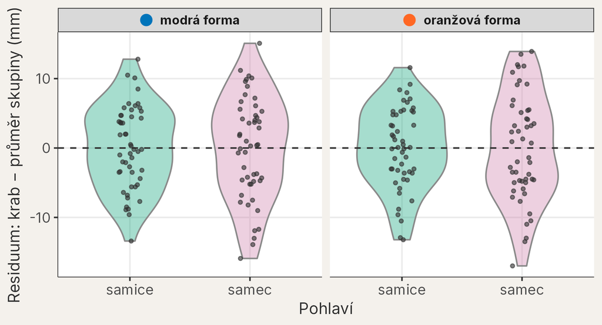

Residuum = délka kraba − průměr jeho skupiny.

## Rozdíl mezi pohlavími závisí na barevné formě

- 🔵 Modrá forma: samec − samice = +3,91 mm
- 🟠 Oranžová forma: samec − samice = −0,93 mm
- Změna rozdílu: −4,84 mm; 95% interval spolehlivosti −8,59 až −1,10 mm

Průměrné délky závisejí i na tom, které kraby autoři vybrali. Výsledek popisuje tento soubor, ne velikost krabů v přírodě.

# Když jsou oba prediktory čísla

## Přibude vysokému stromu s každým centimetrem průměru víc dřeva?

Střemcha pozdní

- severoamerický, u nás invazní strom
- objem dřeva z **průměru kmene** a **výšky**
- 31 pokácených stromů, z amerických jednotek převedeno na cm, m a m³

Ve dvojici

Dva stejně tlusté kmeny ztloustnou o 1 cm. Jeden strom je nízký, druhý vysoký.

Kterému přibude víc dřeva?

Vysokému: nová vrstva dřeva obalí delší kmen.

Meyer (1953), *Forest Mensuration* · `data/stromy.csv`

## Vystihne společný sklon nízké i vysoké stromy?

```r
mod_aditivni <-
  lm(
    formula = objem_m3 ~ prumer_cm + vyska_m,
    data = data_stromy
  )
```

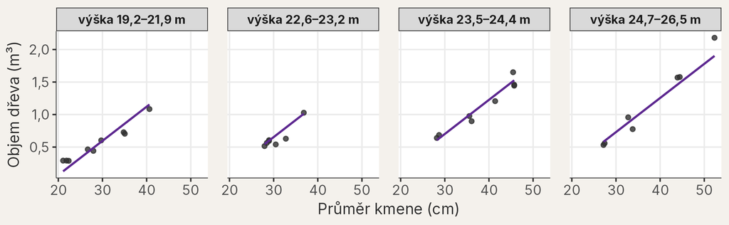

**Ve dvojici:** kde leží tenké a tlusté kmeny v krajních panelech?

Panel = výšková čtvrtina stromů · přímka = model při střední výšce panelu

## Mění se sklon přímky s výškou stromu?

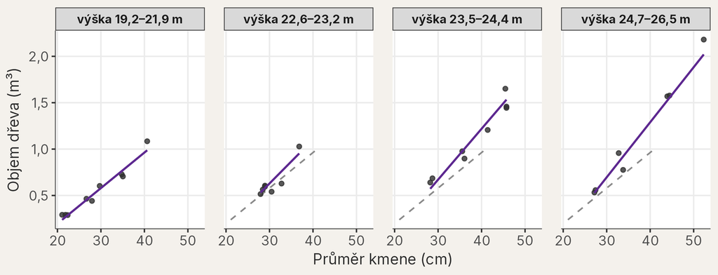

Čím vyšší strom, tím strmější přímka.

Šedá přerušovaná = přímka nejnižšího panelu · sklon = m³ na 1 cm průměru

## `prumer_cm * vyska_m`: sklon průměru závisí na výšce

```r
mod_stromy <-
  lm(
    formula = objem_m3 ~ prumer_cm * vyska_m,
    data = data_stromy
  )
round(x = coef(object = mod_stromy), digits = 5)
```

```
      (Intercept)         prumer_cm           vyska_m prumer_cm:vyska_m
          1.96508          -0.06528          -0.12050           0.00493
```

sklon průměru = `prumer_cm` + `prumer_cm:vyska_m` × výška

| Výška stromu | 21 m | 23 m | 25 m |
| --- | --- | --- | --- |
| Sklon průměru (m³ na 1 cm) | 0,038 | 0,048 | 0,058 |

## Pro který strom platí koeficient `prumer_cm`?

`prumer_cm` = −0,065 m³ na 1 cm

**A)** Pro každý změřený strom.

**B)** Jen pro nejnižší stromy v datech.

**C)** Pro žádný: tlustší kmen má méně dřeva.

**D)** Jen pro strom vysoký 0 m.

Takový strom v datech není. Sklon průměru proto uvádíme při zvolené výšce uvnitř dat.

## Co víme o stromech?

Přibude vysokému stromu s každým centimetrem průměru víc dřeva?

Co data ukazují

- Kmen 36 cm místo 28 cm podle modelu: +0,31 m³ při 21 m, +0,46 m³ při 25 m.
- Sklon průměru (m³ na 1 cm) roste o 0,0049 na každý 1 m výšky (95% interval spolehlivosti 0,0031 až 0,0068).

Co zůstává otevřené

- 31 stromů bez popsaného výběru.
- Rezidua ani vliv jednotlivých stromů jsme nekontrolovali.
- Nepopsal by vztah lépe zakřivený model?

# Jedna myšlenka, tři obrazy

## Interakce mění sklon nebo skupinový rozdíl

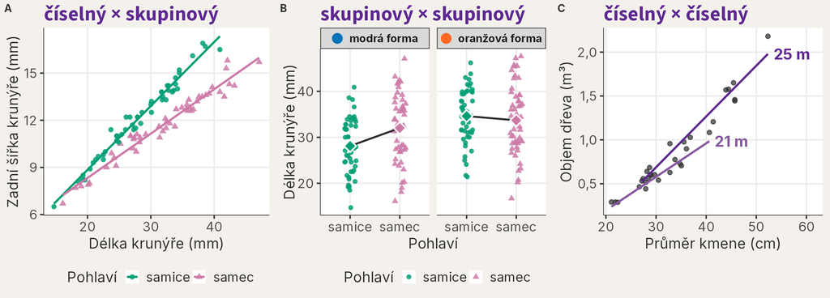

Co se mění? Rozdíl mezi přímkami podél osy délky.

Co se mění? Rozdíl mezi pohlavími podle formy.

Co se mění? Sklon průměru s výškou stromu.

## Co musíme doplnit, aby tvrzení o efektu bylo úplné?

Neúplné

„Délka má efekt.“

„Samci jsou větší.“

„Průměr kmene má efekt.“

Opravte tvrzení

- Pro které pohlaví?
- Při jaké délce?
- V které barevné formě?
- Větší v jakém znaku?
- Při jaké výšce?

V modelu s interakcí vždy uvádíme hodnotu nebo úroveň druhého prediktoru.

## Jak číst model s interakcí?

1. Otázka Mění se vztah nebo rozdíl podle druhého prediktoru?

2. Data a předpovědi Ukažte body a předpovědi pro konkrétní kombinace.

3. Koeficienty Hlavní koeficient platí v referenční skupině nebo při nule druhého prediktoru.

4. Závěr Jen v rozsahu dat a jako souvislost, ne příčina.

## Co si odnést

- Interakci potřebujeme, když vztah jednoho prediktoru závisí na druhém; podpořit ji má biologická otázka i graf.
- `x * y` je zkratka pro `x + y + x:y`.
- Hlavní koeficienty jsou podmíněné; skupiny porovnáváme pomocí předpovědí při zvolené hodnotě.
- U dvou skupinových prediktorů je interakce rozdíl dvou rozdílů.
- U dvou číselných prediktorů se sklon jednoho plynule mění s hodnotou druhého.
- Závěr omezujeme na pozorovaný rozsah a na souvislost v pozorovacích datech.

Data: Campbell, N. A. a Mahon, R. J. (1974) · Meyer, H. A. (1953) · `data/krabi.csv`, `data/stromy.csv`

## Který biologicky smysluplný model máme zvolit?

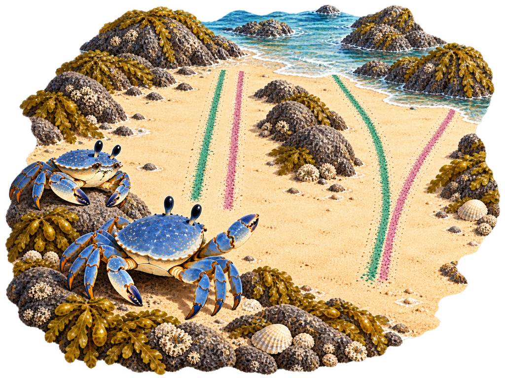

Ilustrace vytvořená pomocí AI.

**Aditivní kandidát**

`zadni_sirka_mm ~`  
`delka_krunyre_mm + pohlavi`

Stálý rozdíl

**Interakční kandidát**

`zadni_sirka_mm ~`  
`delka_krunyre_mm * pohlavi`

Měnící se rozdíl

Jak mezi kandidáty vybírat, ukáže následující lekce.

## Kde byste čekali interakci vy?

Uveďte biologickou otázku, u které byste čekali, že vztah dvou znaků závisí na skupině nebo na hodnotě jiného znaku.

Jak by vypadal graf?